# FML Assignment 2

Priyanka Jonnala

2023-10-01

Required Libraries

```r
library(class)
library(caret)
library(e1071)
```

Read the data.

```r
bankinfo <- read.csv("UniversalBank.csv")
dim(bankinfo)
```

```
## [1] 5000   14
```

```r
t(t(names(bankinfo))) # The t function creates a transpose of the dataframe
```

```
##       [,1]
##  [1,] "ID"
##  [2,] "Age"
##  [3,] "Experience"
##  [4,] "Income"
##  [5,] "ZIP.Code"
##  [6,] "Family"
##  [7,] "CCAvg"
##  [8,] "Education"
##  [9,] "Mortgage"
## [10,] "Personal.Loan"
## [11,] "Securities.Account"
## [12,] "CD.Account"
## [13,] "Online"
## [14,] "CreditCard"
```

Drop ID and ZIP

```r
bankinfo <- bankinfo[,-c(1,5)]
```

Split Data into 60% training and 40% validation. Before we split, let us transform categorical variables into dummy variables

```r
# Only Education needs to be converted to factor
bankinfo$Education <- as.factor(bankinfo$Education)

# Now, convert Education to Dummy Variables

groups <- dummyVars(~., data = bankinfo) # This creates the dummy groups
m_bankinfo <- as.data.frame(predict(groups,bankinfo))


set.seed(1)  # Important to ensure that we get the same sample if we rerun the code
train.index <- sample(row.names(m_bankinfo), 0.6*dim(m_bankinfo)[1])
val.index <- setdiff(row.names(m_bankinfo), train.index)
train.df <- m_bankinfo[train.index,]
val.df <- m_bankinfo[val.index,]
t(t(names(train.df)))
```

```
##       [,1]
##  [1,] "Age"
##  [2,] "Experience"
##  [3,] "Income"
##  [4,] "Family"
##  [5,] "CCAvg"
##  [6,] "Education.1"
##  [7,] "Education.2"
##  [8,] "Education.3"
##  [9,] "Mortgage"
## [10,] "Personal.Loan"
## [11,] "Securities.Account"
## [12,] "CD.Account"
## [13,] "Online"
## [14,] "CreditCard"
```

Now, let us normalize the data

```r
train.norm.df <- train.df[,-10] # Note that Personal Income is the 10th variable
val.norm.df <- val.df[,-10]

norm.values <- preProcess(train.df[, -10], method=c("center", "scale"))
train.norm.df <- predict(norm.values, train.df[, -10])
val.norm.df <- predict(norm.values, val.df[, -10])
```

### Questions

Consider the following customer:

1. Age = 40, Experience = 10, Income = 84, Family = 2, CCAvg = 2, Education_1 = 0, Education_2 = 1, Education_3 = 0, Mortgage = 0, Securities Account = 0, CD Account = 0, Online = 1, and Credit Card = 1. Perform a k-NN classification with all predictors except ID and ZIP code using k = 1. Remember to transform categorical predictors with more than two categories into dummy variables first. Specify the success class as 1 (loan acceptance), and use the default cutoff value of 0.5. How would this customer be classified?

```r
# We have converted all categorical variables to dummy variables
# Let's create a new sample
new_customer <- data.frame(
  Age = 40,
  Experience = 10,
  Income = 84,
  Family = 2,
  CCAvg = 2,
  Education.1 = 0,
  Education.2 = 1,
  Education.3 = 0,
  Mortgage = 0,
  Securities.Account = 0,
  CD.Account = 0,
  Online = 1,
  CreditCard = 1
)

# Normalize the new customer
new.cust.norm <- new_customer
new.cust.norm <- predict(norm.values, new.cust.norm)
```

Now, let us predict using knn

```r
knn.pred1 <- class::knn(train = train.norm.df,
                       test = new.cust.norm,
                       cl = train.df$Personal.Loan, k = 1)
knn.pred1
```

```
## [1] 0
## Levels: 0 1
```

2. What is a choice of k that balances between overfitting and ignoring the predictor information?

```r
# Calculate the accuracy for each value of k
# Set the range of k values to consider

accuracy.df <- data.frame(k = seq(1, 15, 1), overallaccuracy = rep(0, 15))
for(i in 1:15) {
  knn.pred <- class::knn(train = train.norm.df,
                         test = val.norm.df,
                         cl = train.df$Personal.Loan, k = i)
  accuracy.df[i, 2] <- confusionMatrix(knn.pred,
                                       as.factor(val.df$Personal.Loan),positive = "1")$overall[1]
}

which(accuracy.df[,2] == max(accuracy.df[,2]))
```

```
## [1] 3
```

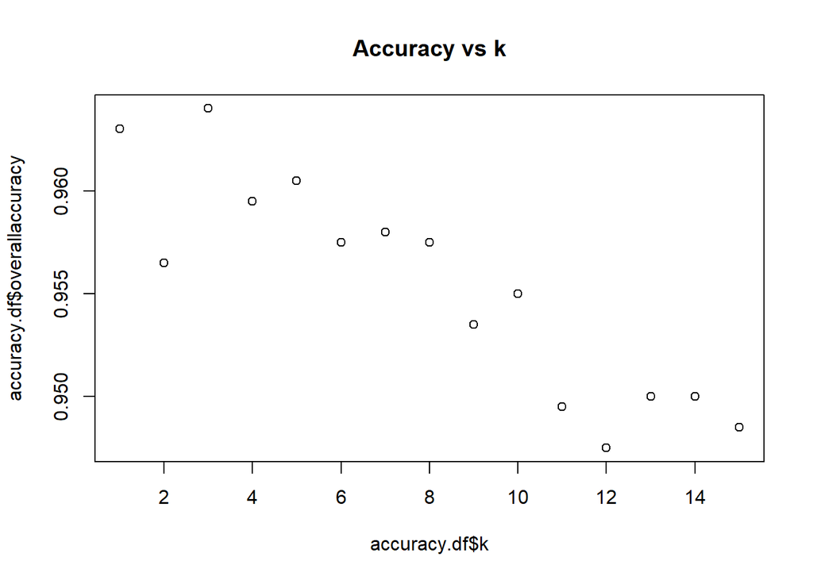

```r
#To find the best k value
plot(accuracy.df$k,accuracy.df$overallaccuracy,main = "Accuracy vs k")
```

3. Show the confusion matrix for the validation data that results from using the best k.

```r
knn.pred2 <- class::knn(train = train.norm.df,
                         test = val.norm.df,
                         cl = train.df$Personal.Loan, k = 3)
knn.pred2
```

[output not shown]

[output cut: 41 more lines]

```r
confusionMatrix(knn.pred2,as.factor(val.df$Personal.Loan),positive = "1")
```

```
## Confusion Matrix and Statistics
##
##           Reference
## Prediction    0    1
##          0 1786   63
##          1    9  142
##
##                Accuracy : 0.964
##                  95% CI : (0.9549, 0.9717)
##     No Information Rate : 0.8975
##     P-Value [Acc > NIR] : < 2.2e-16
##
##                   Kappa : 0.7785
##
##  Mcnemar's Test P-Value : 4.208e-10
##
##             Sensitivity : 0.6927
##             Specificity : 0.9950
##          Pos Pred Value : 0.9404
##          Neg Pred Value : 0.9659
##              Prevalence : 0.1025
##          Detection Rate : 0.0710
##    Detection Prevalence : 0.0755
##       Balanced Accuracy : 0.8438
##
##        'Positive' Class : 1
##
```

4. Consider the following customer: Age = 40, Experience = 10, Income = 84,Family = 2, CCAvg = 2, Education_1 = 0, Education_2 = 1, Education_3 = 0,Mortgage = 0, Securities Account = 0, CD Account = 0, Online = 1 and CreditCard = 1. Classify the customer using the best k.

```r
new_customer1 <- data.frame(
  Age = 40,
  Experience = 10,
  Income = 84,
  Family = 2,
  CCAvg = 2,
  Education.1 = 0,
  Education.2 = 1,
  Education.3 = 0,
  Mortgage = 0,
  Securities.Account = 0,
  CD.Account = 0,
  Online = 1,
  CreditCard = 1
)

# Normalize the second customer
new.cust.norm1 <- new_customer1
new.cust.norm1 <- predict(norm.values, new.cust.norm1)
```

Using the best k value to predict the second customer

```r
knn.pred3 <- class::knn(train = train.norm.df,
                       test = new.cust.norm1,
                       cl = train.df$Personal.Loan, k = 3)
knn.pred3
```

```
## [1] 0
## Levels: 0 1
```

5. Repartition the data, this time into training, validation, and test sets (50% : 30% : 20%). Apply the k-NN method with the k chosen above. Compare the confusion matrix of the test set with that of the training and validation sets. Comment on the differences and their reason.

```r
set.seed(2)
train.index1 <- sample(row.names(m_bankinfo), 0.5*dim(m_bankinfo)[1])
train.df1 <- m_bankinfo[train.index1,]
val.index1 <- setdiff(row.names(m_bankinfo), train.index1)
val.df1 <- m_bankinfo[val.index1,]
val.index2 <- sample(row.names(val.df1),0.6*dim(val.df1)[1])
val.df2 <- val.df1[val.index2,]
test.index1 <- setdiff(row.names(val.df1),val.index2)
test.df1 <- val.df1[test.index1,]
```

Normalizing the data

```r
train.norm.df1 <- train.df1[, -10]
val.norm.df2 <- val.df2[, -10]
test.norm.df1 <- test.df1[, -10]
norm.values1 <- preProcess(train.df1[, -10],method = c("center","scale"))
train.norm.df1 <- predict(norm.values1, train.df1[, -10])
val.norm.df2 <- predict(norm.values1, val.df2[, -10])
test.norm.df1 <- predict(norm.values1,test.df1[, -10])
```

KNN prediction of training data set

```r
knn.pred4 <- class::knn(train = train.norm.df1,
                       test = train.norm.df1,
                       cl = train.df1$Personal.Loan, k = 3)
knn.pred4
```

[output not shown]

[output cut: 54 more lines]

Matrix of Training Data Set

```r
confusion_matrix <-confusionMatrix(knn.pred4,as.factor(train.df1$Personal.Loan))
confusion_matrix
```

```
## Confusion Matrix and Statistics
##
##           Reference
## Prediction    0    1
##          0 2246   61
##          1    5  188
##
##                Accuracy : 0.9736
##                  95% CI : (0.9665, 0.9795)
##     No Information Rate : 0.9004
##     P-Value [Acc > NIR] : < 2.2e-16
##
##                   Kappa : 0.8365
##
##  Mcnemar's Test P-Value : 1.288e-11
##
##             Sensitivity : 0.9978
##             Specificity : 0.7550
##          Pos Pred Value : 0.9736
##          Neg Pred Value : 0.9741
##              Prevalence : 0.9004
##          Detection Rate : 0.8984
##    Detection Prevalence : 0.9228
##       Balanced Accuracy : 0.8764
##
##        'Positive' Class : 0
##
```

KNN prediction of Validation data set

```r
knn.pred5 <- class::knn(train = train.norm.df1,
                       test = val.norm.df2,
                       cl = train.df1$Personal.Loan, k = 3)
knn.pred5
```

[output not shown]

[output cut: 27 more lines]

Matrrix of Validation Data Set(30%)

```r
confusion_matrix1 <-confusionMatrix(knn.pred5,as.factor(val.df2$Personal.Loan))
confusion_matrix1
```

```
## Confusion Matrix and Statistics
##
##           Reference
## Prediction    0    1
##          0 1336   64
##          1    7   93
##
##                Accuracy : 0.9527
##                  95% CI : (0.9407, 0.9629)
##     No Information Rate : 0.8953
##     P-Value [Acc > NIR] : 7.433e-16
##
##                   Kappa : 0.6992
##
##  Mcnemar's Test P-Value : 3.012e-11
##
##             Sensitivity : 0.9948
##             Specificity : 0.5924
##          Pos Pred Value : 0.9543
##          Neg Pred Value : 0.9300
##              Prevalence : 0.8953
##          Detection Rate : 0.8907
##    Detection Prevalence : 0.9333
##       Balanced Accuracy : 0.7936
##
##        'Positive' Class : 0
##
```

KNN prediction of test data set

```r
knn.pred6 <- class::knn(train = train.norm.df1,
                       test = test.norm.df1,
                       cl = train.df1$Personal.Loan, k = 3)
knn.pred6
```

[output not shown]

Matrix of Test Data Set(20%)

```r
confusion_matrix2 <-confusionMatrix(knn.pred6,as.factor(test.df1$Personal.Loan))
confusion_matrix2
```

```
## Confusion Matrix and Statistics
##
##           Reference
## Prediction   0   1
##          0 922  28
##          1   4  46
##
##                Accuracy : 0.968
##                  95% CI : (0.9551, 0.978)
##     No Information Rate : 0.926
##     P-Value [Acc > NIR] : 1.208e-08
##
##                   Kappa : 0.7256
##
##  Mcnemar's Test P-Value : 4.785e-05
##
##             Sensitivity : 0.9957
##             Specificity : 0.6216
##          Pos Pred Value : 0.9705
##          Neg Pred Value : 0.9200
##              Prevalence : 0.9260
##          Detection Rate : 0.9220
##    Detection Prevalence : 0.9500
##       Balanced Accuracy : 0.8087
##
##        'Positive' Class : 0
##
```

Comparing and commenting on the Confusion Matrices

1.Training set confusion matrix The training set typically gets the best results because the model is already trained on this data. It gets more true positives and true negatives,and less false positives and false negatives.This is because the model is already trained well and sometimes it even memorizes it.

2.Validation set confusion matrix The validation set gives a realistic view of model’s performance as it wasn’t part of the training. It gets more balanced results with moderate values for true positives, true negatives, false positives, false negatives.